[figure not shown]

# R для тервера и матстата. Проверка гипотез. Доля, Среднее, Дисперсия.

## Agenda

- Как проверять гипотезы
- Точные и асимптотические критерии
- Гипотезы о долях
- Гипотезы о средних
- Гипотезы о дисперсиях

```r
# Точно такой же рисунок для хи-квадрат
chi_stat_picture <- function(chi_stat, n, alpha =0.05, alternative = 'two-sided'){
    # Опции для размеров графика
    options(repr.plot.width=6, repr.plot.height=3)

    # Какие области надо закрасить (зависит от алтиернативы)
    if(alternative == 'two-sided'){
        chi_crit1 <- qchisq(1-(alpha/2), df=n)
        chi_crit2 <- qchisq(alpha/2, df=n)
        dlimit_left  <- limitRange(function(x) dchisq(x, df=n), 0, chi_crit2)
        dlimit_right <- limitRange(function(x) dchisq(x, df=n), chi_crit1, Inf)
        }
    if(alternative == 'less'){
        chi_crit2 <- qchisq(alpha,df=n)
        dlimit_left  <- limitRange(function(x) dchisq(x, df=n), 0, chi_crit2)
        dlimit_right <- limitRange(function(x) dchisq(x, df=n), Inf, Inf)
    }
    if(alternative == 'greater'){
        chi_crit1 <- qchisq(1 - alpha,df=n)
        dlimit_left  <- limitRange(function(x) dchisq(x, df=n), 0, 0)
        dlimit_right <- limitRange(function(x) dchisq(x, df=n), chi_crit1, Inf)
        }

    # Основная картинка
    p <- ggplot(data.frame(x=c(0, qchisq(1-(alpha/2), df=n) + 10)), aes(x = x))+
       stat_function(fun=dchisq, args = list(df=n)) +  # вся функция
       stat_function(fun=dlimit_left, geom="area",  fill="blue", alpha=0.2) +
       stat_function(fun=dlimit_right, geom="area", fill="blue", alpha=0.2) +
       geom_point(aes(x=chi_stat,y=0), color="red", size=2) +
       geom_vline(xintercept = chi_stat, size=0.3, linetype="dashed", color="red") +
       annotate("text", label=round(chi_stat,2), x= chi_stat, y=0.2, parse=T, size=4, color="darkred")

    # Рисуем критические точки
    if(alternative == 'two-sided'){
       p <- p + annotate("text", label=round(chi_crit1,2), x=chi_crit1+0.1, y=-0.02, parse=T, size=4) +
                annotate("text", label=round(chi_crit2,2), x=chi_crit2-0.1, y=-0.02, parse=T, size=4)
        }
    if(alternative == 'less'){
       p <- p + annotate("text", label=round(chi_crit2,2), x=chi_crit2-0.1, y=-0.02, parse=T, size=4)
        }
    if(alternative == 'greater'){
       p <- p + annotate("text", label=round(chi_crit1,2), x=chi_crit1+0.1, y=-0.02, parse=T, size=4)
        }

    # Немного заключительных настроек, связанных с темой и вывод на экран
    p <- p + theme(
             axis.text.x = element_blank(),
             axis.text.y = element_blank(),
             axis.ticks = element_blank(),
             axis.title.x = element_blank(),
             axis.title.y = element_blank()
            )

    return(p)
}
```

# 1. Что такое гипотезы и зачем их проверять

#### Примеры гипотез:

- В Австралии женщин дискриминируют на рынке труда!
- В Питере люди любят кофе больше, чем в москве!
- Посетители постоянно покупают в паре пиво и подгузники. Мы могли бы использовать это, чтобы увеличить прибыль.
- Осьминог Пауль - настоящий прорицатель! Его предсказания всегда сбываются!
- Доходности по акциям Яндекса имеют нормальное распределение!

### Что делать с гипотезами

- Можно собирать данные и смотреть не противоречат ли им гипотезы
- Это не очень достоверно, надо быть готовым к ошибкам
- Гипотезы нельзя принмать, их не отвергают

[figure not shown]

### Эксперимент

- Завязываем агенту глаза, предлагаем взболтанный и смешанный мартини
- Если больше понравился взболтанный $X_i = 1$

[figure not shown]

### Формализация гипотезы

$$ \begin{aligned} H_0: & \quad \text{Джеймс бонд не различает напитки} \\ H_1: & \quad \text{Бонд различает напитки} \end{aligned} $$

Выбока: $X_1, \ldots, X_n$. Если Бонд не различает два напитка, он берёт их наугад. Сформулируем это в терминах $X \sim Bern(p)$.

$$ \begin{aligned} H_0: & \quad p = 0.5 \\ H_1: & \quad p \ne 0.5 \end{aligned} $$

### Формализация гипотезы

- Пусть $10$ экспериментов показали, что $\hat{p}=0.6$
- Джеймс Бонд различает?
- Да! Число 0.6 больше, чем 0.5!
- $\hat{p}$ - случайная величина, если продолжим собирать выборку, может измениться
- Хотим узнать при текущем объёме выборки насколько $\hat{p}$ близко к $0.5$

$$\hat p \overset{asy}{\sim} N \left(p, \frac{p(1-p)}{n} \right)$$

$$ P\left(\hat{p} - 1.96 \cdot \sqrt{\frac{\hat{p} \cdot (1 - \hat{p})}{n}} \le p \le \hat{p} + 1.96 \cdot \sqrt{\frac{\hat{p} \cdot (1 - \hat{p})}{n}} \right) = 0.95 $$

```r
p_hat = 0.6
n = 10

sd_p = sqrt(p_hat*(1-p_hat)/n)
p_left  = p_hat - qnorm(1-0.05/2)*sd_p
p_right = p_hat + qnorm(1-0.05/2)*sd_p
cat('Параметр p с вероятностью 95% лежит между',p_left, 'и', p_right, '\n')
cat('Ширина интервала:', p_right - p_left)
```

```
Параметр p с вероятностью 95% лежит между 0.2963637 и 0.9036363
Ширина интервала: 0.6072726
```

Мы знаем, что

$$ \hat p \overset{asy}{\sim} N \left(p, \frac{p(1-p)}{n} \right) $$

Если нулевая гипотеза верна, тогда истиное значение $p$ будет равно $0.5$ и

$$ \hat p \overset{asy}{\sim} N \left(0.5, \frac{0.5(1-0.5)}{10} \right) $$

Расстояние до $0.5$ будет распределено с нулевым математическим ожиданием

$$ \hat p - 0.5 \overset{asy}{\sim} N \left(0, \frac{0.5(1-0.5)}{10} \right) $$

Поделим всё это для удобства на стандартное отклонение и получим **статистику** для проверки гипотезы

$$ \frac{\hat p - 0.5}{\sqrt{\frac{0.5(1-0.5)}{10}}} \overset{asy}{\sim} N (0,1). $$

### Мера близости

- Мы выяснили как распределно "расстояние" до значения $0.5$ при верности нулевой гипотезы
- Осталось выбрать порог, при котором мы будем считать, что $H_0$ верна
- Если альтернатива двусторонняя, очень большие и очень маленькие значения статистики говорят против нашей гипотезы

### Уровень значимости

- Если мы отвергаем $H_0$, когда она верна - мы ошибаемся
- Фиксируем число ошибок, $\alpha$ - уровень значимости (обычно берут 1% 5% или 10%)
- Если мы упаковываем $100$ парашютов на уровне значимости $5\%$, то пять парашютистов умрут, и мы готовы с этим смириться
- Если статистика попала в $1-\alpha$% доверительный интервал, то данные не противоречат гипотезе

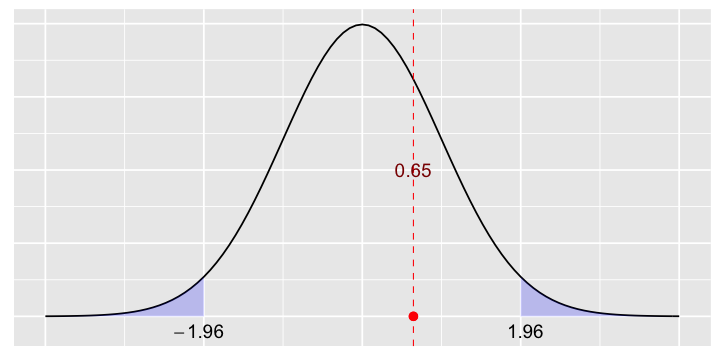

```r
p_hat = 0.6
n = 10

sd_p = sqrt(p_hat*(1-p_hat)/n)

z_stat = (p_hat - 0.5)/sd_p   # считаем наблюдаемую статистику
z_stat_picture(z_stat, alpha = 0.05, alternative = 'two-sided')
```

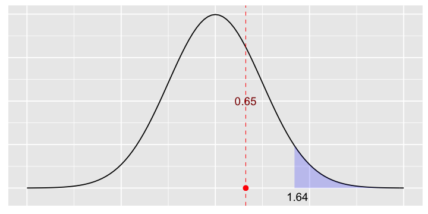

```r
z_stat_picture(z_stat, alpha = 0.05, alternative = 'greater')
```

### Алгоритм проверки гипотез

1. Задаём уровень значимости $\alpha$ (сколько парашютистов погибнут).
2. Формулируем нулевую и альтернативную гипотезы.
3. Выбираем статистику для проверки гипотезы.
4. Находим наблюдаемое значение статистики по выборке.
5. Находим критические точки для выбранной статистики. Именно для этого нам нужно знать её распределение.
6. Сравниваем наблюдаемое значение с критическими. Если оно попало в критическую область, отвергаем нулевую гипотезу. Если нет, то не отвергаем.

# 2. Ошибки, которые мы можем совершить

| $\mbox{ }$ | $H_0$ верна | $H_0$ не верна |
| --- | --- | --- |
| $H_0$ не отвергается | ok | Ошибка $2$ рода |
| $H_0$ отвергается | Ошибка $1$ рода | ok |

- Вероятность ошибки первого рода, $P(H_0 \text{ отвергнута} \mid H_0 \text{ верна})$, называют **уровнем значимости** и обозначают как $\alpha$.
- Вероятность ошибки второго рода, $P(H_0 \text{ не отвергнута} \mid H_0 \text{ не верна})$, обозначают как $\beta$. Величину $1-\beta$ называют **мощностью критерия.** Критерий с наибольшей мощностью - классный.

### Презумпция нулевой гипотезы

- Ошибки первого и второго рода неравнозначны, ошибка первого рода критичнее (фиксируем её в начале)
- Ошибка второго рода минимизируется по остаточному принципу

> **Презумпция невиновности:** подсудимый по умолчанию невиновен. Если нет доказательств обратному, нельзя утверждать, что он преступник, даже если он совершил преступление.

[figure not shown]

# 3. P-value

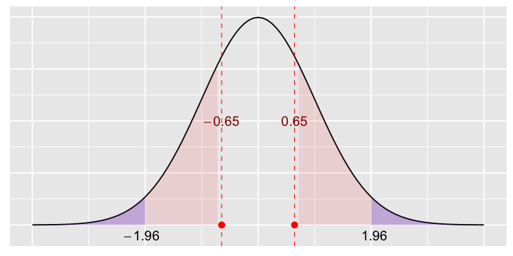

```r
dlimit_left  <- limitRange(dnorm, -Inf, -z_stat)
dlimit_right <- limitRange(dnorm, z_stat, Inf)

z_stat_picture(z_stat, alpha = 0.05, alternative = 'two-sided') +
    # Делаем красную заливку
    stat_function(fun=dlimit_left, geom="area",  fill="red", alpha=0.1) +
    stat_function(fun=dlimit_right, geom="area", fill="red", alpha=0.1) +
    # Добавляем симметричкую пунктирную линию
    geom_point(aes(x=-z_stat,y=0), color="red", size=2) +
    geom_vline(xintercept = -z_stat, size=0.3, linetype="dashed", color="red") +
    annotate("text", label=round(-z_stat,2), x= -z_stat, y=0.2, parse=T, size=4, color="darkred")
```

### Подсчёт pvalue

```r
z_stat
```

0.645497224367903

```r
2*pnorm(-z_stat)
```

0.518605016428726

> p-значение упрощает проверку гипотез. В нашем случае оно больше уровня значимости, следовательно гипотеза не отвергается.

**Вопрос:** а какой уровень значимости надо выбрать, чтобы гипотеза впервые отверглась?

### Более формально

**Достигаемый уровень значимости** или **P-значение** - это вероятность при справедливости нулевой гипотезы получить такое же значение статистики, как в эксперименте или ещё более экстремальное.

</br>

$$p = P(z \ge z_{\text{набл.}} \mid H_0)$$

# 4. Параметрические критерии

- Обычно нас интересуют средние, доли и дисперсии
- Будем проверять гипотезы о них
- Каждый критерий для проверки гипотезы - небольшая теорема со своими предпосылками
- Сегодня посмотрим параметрические критерии
- В гипотезах для таких критериев высказывается предположение о значении параметра распределения, из которого предположительно поступила выборка

# 5. Доля

## 5.1 Z-критерий для доли

**Выборка:**

$$X_1, \ldots, X_n \sim iid \hspace{1mm} Ber(p)$$

**Нулевая и альтернативная гипотезы:**

$$ \begin{aligned} &H_0: \hspace{2mm} p = p_0 \\ &H_1: \hspace{2mm} p < \ne > p_0 \end{aligned} $$

**Асимптотическое распределение оценки $\hat p = \bar x$ при верности нулевой гипотезы:**

$$ \hat p \overset{asy}{\sim} N\left(p_0, \frac{p_0(1-p_0)}{n} \right) $$

**Статистика для проверки гипотезы:**

$$ Z = \frac{\hat p - p_0}{\sqrt{\frac{p_0(1-p_0)}{n}}} \overset{asy}{\sim} N(0,1) $$

### Задачка про присяжных

- В 70-х годах известный педиатр и автор книг по воспитанию детей Бенджамин Спок был арестован за участие в антивоенной демонстрации. Его дело должен был рассматривать суд присяжных.
- Присяжные назначаются многоступенчатой процедурой. На очередном этапе остаётся 300 человек, из которых отбираются финальные 12.
- В процессе Бенджамина Спока среди этих 300 только 90 были женщинами
- Протест адвокатов. Обвинение специально пытается сделать итоговый состав благосклонным к подсудимому, убирая женщин.
- Был ли отбор беспристрастным?

```r
# Что делать?
```

```
p-value: 2.131096e-12
```

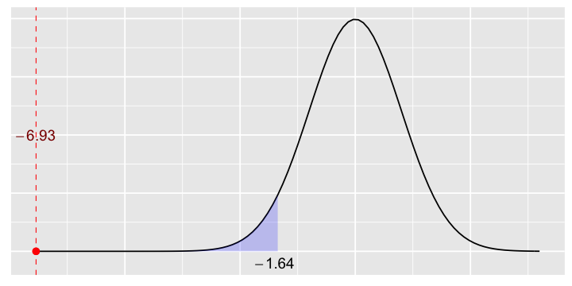

```r
n = 300
p_hat = 90/300
z_stat = (p_hat - 0.5)/sqrt(0.5*(1-0.5)/n)
p_value = pnorm(z_stat)
cat('p-value:',p_value)
z_stat_picture(z_stat, alpha = 0.05, alternative = 'less')
```

```
p-value: 4.262192e-12
```

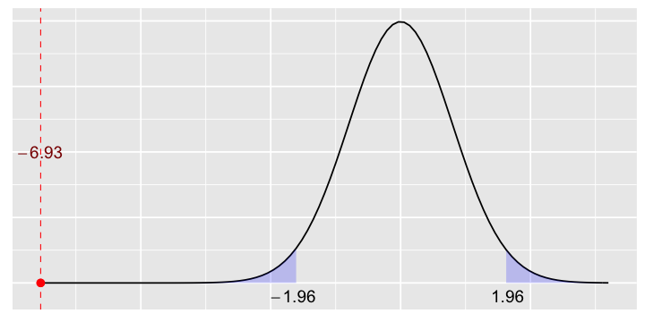

```r
n = 300
p_hat = 90/n

# Вручную
z_stat = (p_hat - 0.5)/sqrt(0.5*(1-0.5)/n)
z_stat_picture(z_stat, alpha = 0.05, alternative = 'two-sided')
p_value = 2*pnorm(z_stat)
cat('p-value:',p_value)
```

Наши выводы это никак не поменяет. Сделаем то же самое во встроенном в R пакете. Это позволяеь сделать команда [`prop.test`.](http://stat.ethz.ch/R-manual/R-devel/library/stats/html/prop.test.html)

```r
test_res = prop.test(90, 300, p = 0.5, alternative = "less",
                     conf.level = 0.95, correct = FALSE)
test_res
```

```
	1-sample proportions test without continuity correction

data:  90 out of 300, null probability 0.5
X-squared = 48, df = 1, p-value = 2.131e-12
alternative hypothesis: true p is less than 0.5
95 percent confidence interval:
 0.0000000 0.3451483
sample estimates:
  p
0.3
```

```r
test_res$p.value
test_res$estimate
```

2.13109579892183e-12

**p:** 0.3

## 5.2 Z-критерий для доли для двух независимых выборок

**Выборки:**

$$ \begin{aligned} & X_1, \ldots, X_{n_1} \sim iid \hspace{1mm} Ber(p) \\ & Y_1, \ldots, Y_{n_2} \sim iid \hspace{1mm} Ber(p) \end{aligned} $$

**Нулевая и альтернативная гипотезы:**

$$ \begin{aligned} &H_0: \hspace{2mm} p_1 = p_2 \\ &H_1: \hspace{2mm} p_1 < \ne > p_2 \end{aligned} $$

**Асимптотическое распределения оценок $\hat p_1 = \bar x$ и $\hat p_2 = \bar y$ при верности нулевой гипотезы:**

$$ \hat p_1 \overset{asy}{\sim} N\left(p, \frac{p(1-p)}{n_1} \right) $$$$ \hat p_2 \overset{asy}{\sim} N\left(p,\frac{p(1-p)}{n_2} \right) $$

Значит статистика $\hat p_1 - \hat p_2$ тоже будет иметь нормальное распределение. Найдём её параметры:

$$ \begin{aligned} & E(\hat p_1 - \hat p_2) = p - p = 0 & Var(\hat p_1 - \hat p_2) = p(1-p)\frac{n_1 + n_2}{n_1 \cdot n_2} \end{aligned} $$

Статистика для проверки гипотезы:

$$ Z = \frac{\hat p_1 - \hat p_2}{\sqrt{P(1-P)\frac{n_1 + n_2}{n_1 n_2}}} \overset{asy}{\sim} N(0,1), $$

где $P = \frac{m_1 + m_2}{n_1 + n_2} = \frac{\hat p_1 n_1 + \hat p_2 n_2}{n_1 + n_2}$

### Рейтинг премьер-министра

1600 гражданам Великобритании с правом голоса задают вопрос: одобряют ли они деятельность премьер-министра. 944 человека говорят, что одобряют. Через 6 месяцев опрос повторяется. На этот раз из 1600 опрошенных 880 говорят, что поддерживают премьер-министра. Нужно понять изменился ли рейтинг премьер-министра.

```r
# Что делать?
```

```
p-value: 0.02229829
```

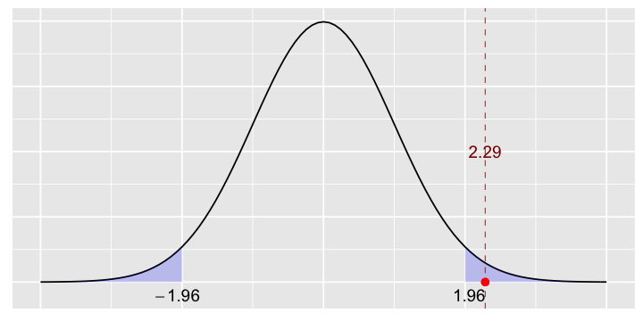

```r
n1 = 1600
m1 = 944

n2 = 1600
m2 = 880

p1_hat = m1/n1
p2_hat = m2/n2
P = (m1 + m2)/(n1 + n2)

z_stat = (p1_hat - p2_hat)/(sqrt(P*(1-P)*(n1+n2)/(n1*n2)))

z_stat_picture(z_stat, alpha = 0.05, alternative = 'two-sided')
p_value = 2*pnorm(-z_stat)
cat('p-value:',p_value)
```

```r
test_res = prop.test(x = c(m1, m2), n = c(n1, n2), correct = FALSE)
test_res
```

```
	2-sample test for equality of proportions without continuity
	correction

data:  c(m1, m2) out of c(n1, n2)
X-squared = 5.2224, df = 1, p-value = 0.0223
alternative hypothesis: two.sided
95 percent confidence interval:
 0.005721636 0.074278364
sample estimates:
prop 1 prop 2
  0.59   0.55
```

## 5.3 Z-критерий для доли для двух связанных выборок

- В обоих опросах участвовали одни и те же люди, выборки связаны между собой
- Z критерий предполагает, что выборки независимы
- Нужен другой критерий

Мы можем перенести собранные по выборке данные в небольшую табличку

| $\mbox{ } $ | + | - | $\Sigma$ |
| --- | --- | --- | --- |
| + | 794 | 150 | 944 |
| - | 86 | 570 | 656 |
| $\Sigma$ | 880 | 720 | 1600 |

| $\mbox{ } $ | + | - | $\Sigma$ |
| --- | --- | --- | --- |
| + | e | f | e+f |
| - | g | h | g+h |
| $\Sigma$ | e+g | f+h | n |

Если мы будем расчитывать итоговую статистику как

$$ Z = \frac{f - g}{\sqrt{f + g - \frac{(f-g)^2}{n}}} \overset{asy}{\sim} N(0,1), $$

то мы внутри неё учтём только недиагональные элементы. То есть только те объекты, на которых значение в выборке различаются. Грубо говоря, это позволит нам подчистить нашу выборку от взаимосвязей.

```
p-value: 2.804011e-05
```

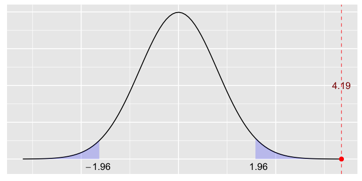

```r
n = 1600
f = 150
g = 86

z_stat = (f - g)/(sqrt(f + g - (f-g)^2/n))

z_stat_picture(z_stat, alpha = 0.05, alternative = 'two-sided')
p_value = 2*pnorm(-z_stat)
cat('p-value:',p_value)
```

### Резюме про доли

- Проверять гипотезы о долях помогает Z-тест
- Он имеет асимптотически нормальное распределение
- Статистика для связных выборок и независимых считается немного по-разному
- Обе имеют асимптотически нормальное распределение

# 6. Среднее

## 6.1 Гипотезы о среднем для нормального распределения

**Выборка:**

$$ X_1, \ldots, X_n \sim iid \hspace{1mm} N(\mu, \sigma^2) $$

**Нулевая и альтернативная гипотезы:**

$$ \begin{aligned} &H_0: \hspace{2mm} \mu = \mu_0 \\ &H_1: \hspace{2mm} \mu < \ne > \mu_0 \end{aligned} $$

**Распределение оценки $\hat \mu = \bar x$ при верности нулевой гипотезы:**

$$ \hat \mu \sim N\left(\mu_0, \frac{\sigma^2}{n} \right) $$

**Статистика для проверки гипотезы:**

$$ Z = \frac{\hat \mu - \mu_0}{\frac{\sigma}{\sqrt{n}}} \sim N(0,1) $$

- Обратите внимание, что из-за нормальности распределения это распределение является **точным,** а не асимптотическим. Это очень важная деталь.
- Обратите внимание на дисперсию. Про неё в нулевой гипотезе не делается никаких предположений. Она уже заранее должна быть для нас известна. Если это так, то с распределением всё хорошо и можно проверять гипотезу.

$$ \hat \mu \sim N\left(\mu_0, \frac{\sigma^2}{n} \right) $$

С дисперсией чуток сложнее. По Тореме Фишера, если генеральная совокупность имеет нормальное распределение, то статистика

$$ \frac{(n-1) \cdot s^2}{\sigma^2} \sim \chi^2_{n-1} $$

$$ \frac{\hat \mu - \mu_0}{\frac{s}{\sqrt{n}}} = \frac{\hat \mu - \mu_0}{\frac{\sigma}{\sqrt{n}}} : \sqrt{\frac{1}{n-1} \frac{(n-1) s^2}{\sigma^2}} \sim \frac{N(0,1)}{\sqrt{\frac{\chi^2_{n-1}}{n-1}}} = t_{n-1} $$

### Вес детей при рождении

- Средний вес детей при рождении 3300 г, у женщин, живущих за чертой бедности - 2800 г
- 25 женщин, живущих за чертой бедности, участвовали в экспериментальной программе ведения беременности
- Средний вес их детей составил 3075 г, стандартное отклонение 500 г
- Эффективна ли программа?

```r
# Что делать?
```

В качестве альтернативы берём правостороннюю, так как вес детей должен был возрасти

$$ \begin{aligned} &H_0: \hspace{2mm} \mu = 2800 \hspace{2mm} \text{Программа не помогла}\\ &H_1: \hspace{2mm} \mu > 2800 \hspace{2mm} \text{Программа помогла} \end{aligned} $$

Теоретическая дисперсия неизвестна. Её придётся оценивать. Из-за этого будем использовать $t-$статистику.

```
p-value: 0.005573915
```

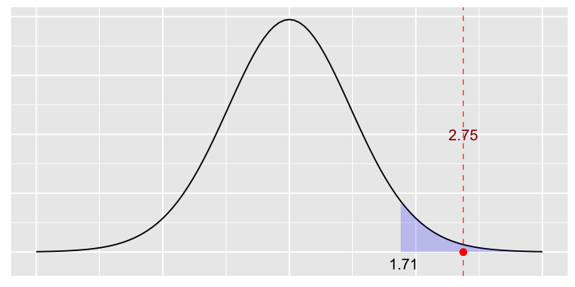

```r
mu_0 = 2800

mu_hat = 3075
s = 500
n = 25

t_stat = sqrt(n)*(mu_hat - mu_0)/s

# обратите внимание, что p-value теперь мы считаем по
# распределению стьюдента! Картинку тоже строим для него
t_stat_picture(t_stat, n, alpha = 0.05, alternative = 'greater')

p_value = pt(-t_stat, df=n-1)
cat('p-value:',p_value)
```

## 6.2 Гипотезы о среднем в общем случае

Если выборка не распределена нормально, то наша оценка для среднего будет иметь **асимптотически нормальное** распределение:

$$ \hat \mu \overset{asy}{\sim} N\left(\mu_0, \frac{\sigma^2}{n} \right) $$

$$ z = \frac{\hat \mu - \mu_0}{\frac{\hat \sigma}{\sqrt{n}}} \overset{asy}{\sim} N(0,1) $$

### Шахты:

В [табличке coal](https://yadi.sk/i/wIFZJJ3X3VdPow) лежит статистика о авариях на угольных шахтах в Британии. Исследователь Андрей считает, что они происходят с интенсивностью $3$ штуки за год. Проверьте на $5\%$ уровне значимости гипотезу об этом.

```r
# Загружаем табличку с данными
df = read.csv('/Users/fulyankin/Yandex.Disk.localized/R/R_prob_data/coal.csv', sep=',')

head(df, 5)  # шапка таблицы
```

| X | year | count |
| --- | --- | --- |
| 1 | 1851 | 4 |
| 2 | 1852 | 5 |
| 3 | 1853 | 4 |
| 4 | 1854 | 1 |
| 5 | 1855 | 0 |

**Гипотеза:**

$$ \begin{aligned} &H_0: \hspace{2mm} \lambda = 3 \\ &H_1: \hspace{2mm} \lambda \ne 3 \end{aligned} $$

Мы знаем, что $\hat \lambda = \bar x$. Воспользуемся асимптотическим критерием для средних. Как можно убедиться ниже, гипотеза отвергается.

```
p-value: 8.811492e-07
```

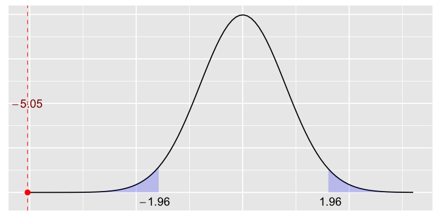

```r
n = nrow(df)
z_stat = (mean(df$count) - 3)/(var(df$count)/sqrt(n))

z_stat_picture(z_stat, alpha = 0.05, alternative = 'two-sided')

p_value = pt(z_stat, df=n-1)
cat('p-value:',p_value)
```

## 6.3 Двухвыборочный критерий стьюдента для независимых выборок

**Выборки:**

$$ \begin{aligned} & X_1, \ldots, X_{n_1} \sim iid \hspace{1mm} N(\mu_1, \sigma_1^2) \\ & Y_1, \ldots, Y_{n_2} \sim iid \hspace{1mm} N(\mu_2, \sigma_2^2) \end{aligned} $$

**Нулевая и альтернативная гипотезы:**

$$ \begin{aligned} &H_0: \hspace{2mm} \mu_1 = \mu_2 \\ &H_1: \hspace{2mm} \mu_1 < \ne > \mu_2 \end{aligned} $$

**Асимптотическое распределения** оценок $\hat \mu_1 = \bar x$ и $\hat \mu_2 = \bar y$ при верности нулевой гипотезы:

$$ \hat \mu_1 \sim N\left(\mu, \frac{\sigma_1}{n_1} \right) $$$$ \hat \mu_2 \sim N\left(\mu,\frac{\sigma_2}{n_2} \right) $$

Значит статистика $\hat \mu_1 - \hat \mu_2$ тоже будет иметь нормальное распределение. Найдём её параметры:

$$ \begin{aligned} & E(\hat \mu_1 - \hat \mu_2) = \mu - \mu = 0 & Var(\hat \mu_1 - \hat \mu_2) = \frac{\sigma_1^2}{n_1} + \frac{\sigma_2^2}{n_2} \end{aligned} $$

**Статистика для проверки гипотезы:**

$$ Z = \frac{\hat \mu_1 - \hat \mu_2}{\sqrt{ \frac{\sigma_1^2}{n_1} + \frac{\sigma_2^2}{n_2}} } $$

И вот тут начинаются проблемы.

## Разные ситуации

- Если дисперсии известны, то $Z \sim N(0,1)$. - Если дисперсии известны и выборки нормально распределены, то

$$ \frac{\hat \mu_1 - \hat \mu_2}{\sqrt{ \frac{\sigma_1^2}{n_1}} + \frac{\sigma_2^2}{n_2}}\sim N(0,1) $$

- Если дисперсии неизвестны, но равны, то

$$ t = \frac{\hat \mu_1 - \hat \mu_2}{\sqrt{ \frac{s^2}{n_1} + \frac{s^2}{n_2}}} \sim t(n_1 + n_2 -2) $$

Дисперсия считается по формуле:

$$ s^2 = \frac{(n_1-1) \cdot s_1^2 + (n_2-1) \cdot s_2^2}{n_1 + n_2 -2} $$

- В более сложных ситуациях, когда диспресии неизвестные и разные, возникает проблема. Если заменить неизвестные дисперсии на выборочные, получим $t$-статистику, которая при выполнении нулевой гипотезы будет распределена по Стьюденту

$$ t = \frac{\hat \mu_1 - \hat \mu_2}{\sqrt{ \frac{s_1^2}{n_1} + \frac{s_2^2}{n_2}} } \sim t(\nu). $$

Но есть две проблемы. Во-первых, число степеней свободы $\nu$ у этого распределения будет считатся по довольно сложной формуле:

$$ \nu = \frac{ \left(\frac{s_1^2}{n_1} + \frac{s_2^2}{n_2} \right)^2 }{ \frac{s_1^4}{n_1^2(n_1 -1)} + \frac{s_2^4}{n_2^2(n_2-1)}} $$

Во-вторых, нулевое распределение будет не точным, а приближённым. Точного решения (то есть точного нулевого распределения для такой статистики) не существует. Это проблема называется [проблемой Беренца-Фишера.](https://ru.wikipedia.org/wiki/Нерешённые_проблемы_статистики) Она говорит, что невозможно точно сравнить две средние величины для выборок, дисперсии которых неизвестны.

Апроксимация, которую мы посмотрели выше, будет достаточно точной в двух ситуациях: когда выборки одинаокового объёма. Либо если знак между $n_1$ и $n_2$ такой же , как между $\sigma_1$ и $\sigma_2$. То есть, если из выборки с большей дисперсией собрано больше наблюдений.

У вас в лекциях были первые две ситуации. Третью ситуацию вы не обсуждали, но я счёл, что вы должны о ней услышать.

### Стоимость домов в Сиэтле

Есть [данные о продажной стоимости](https://yadi.sk/i/Gn5GkSNV3Winsn) недвижимости в Сиэтле для 50 сделок в 2001 году и 50 в 2002. Изменились ли в среднем цены?

```r
df = read.csv('/Users/fulyankin/Yandex.Disk.localized/R/R_prob_data/seattle.csv', sep='\t')
head(df)
```

| Price | Year |
| --- | --- |
| 142.00 | 2002 |
| 232.00 | 2002 |
| 132.50 | 2002 |
| 200.00 | 2002 |
| 362.00 | 2002 |
| 244.95 | 2002 |

```r
# Вытащим цены в отдельные векторы
price_2002 = df[df$Year == 2002,]$Price
price_2001 = df[df$Year == 2001,]$Price
```

```r
# Расчитаем всё необходимое для проверки гипотезы
n_1 = length(price_2001)
n_2 = length(price_2002)

mu_1 = mean(price_2001)
mu_2 = mean(price_2002)

s_1 = var(price_2001)
s_2 = var(price_2002)

t_stat = (mu_1 - mu_2)/sqrt(s_1/n_1 + s_2/n_2)
```

Мы не можем сказать, что дисперсии известны или равны. Придётся использовать сложную статистику со сложной формулой. Либр придётся сначала проверить гипотезу о равенстве дисперсий, а уже затем проверять гипотезу о равенстве математических ожиданий.

```r
a = (s_1/n_1 + s_2/n_2)^2
b = s_1^2/(n_1^2*(n_1-1)) + s_2^2/(n_2^2*(n_2-1))
a/b
```

71.8952170780399

```
p-value: 0.423054
```

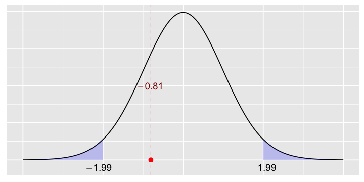

```r
t_stat_picture(t_stat, 72, alpha = 0.05, alternative = 'two-sided')

p_value = 2*pt(t_stat, df=72)
cat('p-value:',p_value)
```

```r
t.test(price_2001, price_2002, var.equal = FALSE,
       alternative = "two.sided", conf.level = 0.95)
```

```
	Welch Two Sample t-test

data:  price_2001 and price_2002
t = -0.80573, df = 71.895, p-value = 0.4231
alternative hypothesis: true difference in means is not equal to 0
95 percent confidence interval:
 -140.11588   59.45468
sample estimates:
mean of x mean of y
 288.9265  329.2571
```

## 6.4 Двухвыборочный критерий стьюдента для связанных выборок

- Измерения делаются на одних и тех же объектах
- Это значит, что $\bar y - \bar x$ это то же самое, что $\overline{x-y}$
- Благодаря тому, что мы можем смотреть прирост по каждому объекту, мы скатываемся к одновыборочному критерию

$$ d_i = X_i - Y_i $$$$ s^2 = \frac{1}{n-1}\sum_{i=1}^n (d_i - \bar d )^2$$$$ t = \frac{\bar{d}}{s/\sqrt{n}} \sim t(n-1)$$

Из-за того, что мы наблюдаем одни и те же объекты, никаких проблем с дисперсией не возникает.

### Лечение детей

- В [таблице](https://yadi.sk/i/-ddOeb363Wipcr) данные о том, как 24 ребёнка прошли тест на способность к подавлению импульсивных поведенческих реакций после недели приёма метилфенидата и после недели приёма плацебо
- Каков эффект препарата?

```r
# Что делать?
```

Препараты принимали одни и те же дети. Выборка является связанной. Поэто будем использовать критерий стьюдента для связанных выборок.

```r
df = read.csv('/Users/fulyankin/Yandex.Disk.localized/R/R_prob_data/ADHD.csv', sep=' ')
head(df)
```

| D0 | D60 |
| --- | --- |
| 57 | 62 |
| 27 | 49 |
| 32 | 30 |
| 31 | 34 |
| 34 | 38 |
| 38 | 36 |

```
p-value: 0.003771488
```

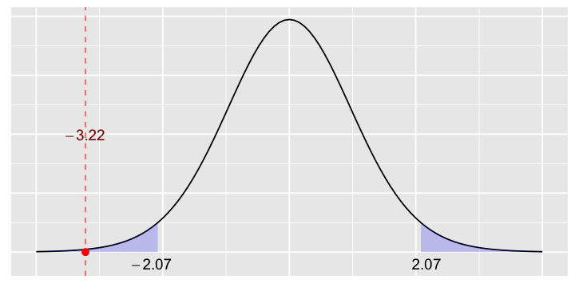

```r
d = df$D0 - df$D60
mu_d = mean(d)
s_d = sd(d)
n = nrow(df)

t_stat = mu_d/(s_d/sqrt(n))

t_stat_picture(t_stat, n-1, alpha = 0.05, alternative = 'two-sided')

p_value = 2*pt(t_stat, df=n-1)
cat('p-value:',p_value)
```

```r
t.test(df$D0, df$D60, var.equal = FALSE, paired=TRUE,
       alternative = "two.sided", conf.level = 0.95)
```

```
	Paired t-test

data:  df$D0 and df$D60
t = -3.2224, df = 23, p-value = 0.003771
alternative hypothesis: true difference in means is not equal to 0
95 percent confidence interval:
 -8.141431 -1.775236
sample estimates:
mean of the differences
              -4.958333
```

Обратите внимание, что если не учесть, что выборки связанные, можно получить неправильный результат и сделать вывод, что лекарство не помогает детям.

```r
t.test(df$D0, df$D60, var.equal = FALSE,
       alternative = "two.sided", conf.level = 0.95)
```

```
	Welch Two Sample t-test

data:  df$D0 and df$D60
t = -1.4522, df = 45.671, p-value = 0.1533
alternative hypothesis: true difference in means is not equal to 0
95 percent confidence interval:
 -11.832593   1.915927
sample estimates:
mean of x mean of y
 39.75000  44.70833
```

## 6.5 Гипотеза о равенстве средних в общем случае

Для проверки гипотезы о равенстве средних для произвольных распределений используют асимптотический тест:

$$ Z = \frac{\hat \mu_1 - \hat \mu_2}{\sqrt{ \frac{s_1^2}{n_1} + \frac{s_2^2}{n_2}} } \overset{asy}{\sim} N(0,1) $$

### Резюме про средние

- Если выборка распределена нормально, можно использовать t-статистику, имеющую распределение стьюдента
- Если средних два и выборки независимы, возможны три разные ситуации
- Если выборки связанные, то всё скатывается к одновыборочному критерию
- Если выборка распределена не нормально, то используются те же статистики, но они имеют асимптотичеси нормальное распределение

# 7. Дисперсии

## 7.1 Гипотезы о дисперсии для нормального распределения

**Выборка:** $X_1, \ldots, X_n \sim iid \hspace{1mm} N(\mu, \sigma^2)$

**Нулевая и альтернативная гипотезы:**

$$ \begin{aligned} &H_0: \hspace{2mm} \sigma^2 = \sigma^2_0 \\ &H_1: \hspace{2mm} \sigma^2 < \ne > \sigma^2_0 \end{aligned} $$

- Если математическое ожидание известно, тогда:

$$\frac{n s^2}{\sigma^2} =\sum_{i=1}^n \left(\frac{X_i - \mu}{\sigma_0}\right)^2 \sim \chi^2_n.$$

Если математическое ожидание неизестно, то используем теорему Фишера и понимаем, что

$$\frac{(n-1) s^2}{\sigma^2} =\sum_{i=1}^n \left(\frac{X_i - \bar x}{\sigma}\right)^2 \sim \chi^2_{n-1}.$$

### Проблема:

Давайте ссимулируем выборку из нормального распределения и проверим обоими критериямигипотезу о дисперсии для него. Будем проверять гипотезу о том, что дисперсия равна $4$ против гипотезы о том, что нет.

```r
y <- rnorm(10, mean = 10, sd = 2)
y[1:10]
```

1. 9.99790625719065

2. 15.2484201238416

3. 9.1598620785111

4. 10.902701621899

5. 9.14487852153923

6. 10.7260326443895

7. 11.4959361493321

8. 11.8211746450618

9. 9.87796043244222

10. 11.8446511546917

Преположим, что нам откуда-то известно математическое ожидание.

9.82427746457542

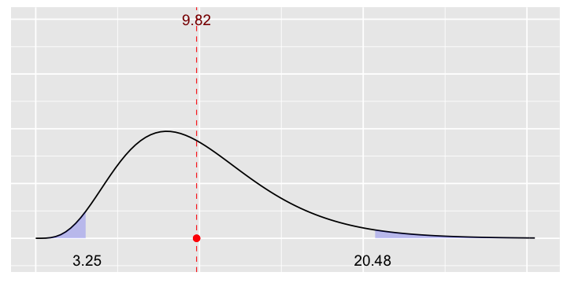

```r
n = length(y)
s2 = 1/n*sum((y-10)^2)

chi_stat = n*s2/4
chi_crit = qchisq(1-0.05/2,df=n)
chi_stat

chi_stat_picture(chi_stat, n)
```

Теперь сделаем то же самое для случая, когда математическое ожидание неизвестно.

7.21331088453479

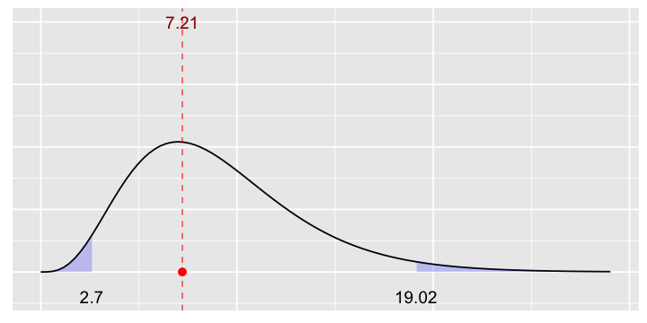

```r
n = length(y)
s2 = var(y)

chi_stat = (n-1)*s2/4
chi_crit = qchisq(1-0.05/2,df=n-1)
chi_stat
chi_stat_picture(chi_stat, n-1)
```

Снова гипотеза не отвергается, но значения статистик при этом получаются другими.

## 7.2 Гипотезы о равенстве дисперсий

**Выборки:**

$$ \begin{aligned} & X_1, \ldots, X_{n_1} \sim iid \hspace{1mm} N(\mu_1, \sigma_1^2) \\ & Y_1, \ldots, Y_{n_2} \sim iid \hspace{1mm} N(\mu_2, \sigma_2^2) \end{aligned} $$

**Нулевая и альтернативная гипотезы:**

$$ \begin{aligned} &H_0: \hspace{2mm} \sigma^2_1 = \sigma^2_2 \\ &H_1: \hspace{2mm} \sigma^2_1 < \ne > \sigma^2_2 \end{aligned} $$

По аналогии с предыдущим пунктом, будем смотреть на то, насколько велико расстояние между двумя дисперсиями:

$$ \frac{s_1^2}{s_2^2} $$

$$ F = \frac{(n_1-1) \cdot s_1^2}{\sigma^2 \cdot (n_1-1)} : \frac{(n_2-1) \cdot s_2^2}{\sigma^2 \cdot(n_2-1)} $$

При верности нулевой гипотезы, получаем, что

$$ F \sim \frac{\chi^2_{n_1-1}}{n_1-1} : \frac{\chi^2_{n_2-1}}{n_2-1} = F(n_1-1,n_2-1). $$

### Проблема:

- Вашему вниманию представлены результаты прыжков в длину Васи Сидорова на двух соревнованиях.
- На первых среди болельщиц присутствовала Аня Иванова (его первая любовь).
- На вторых Аня среди болельщиц не присутствовала.

Проверьте гипотезу, состоящую в том, что отсуствие Ани позволяет Васе лучше сконцентрировтаься и прыгать с большей точность.

```r
# Что делать?
```

```r
first  = c(1.83, 1.64, 2.27, 1.78, 1.89, 2.33, 1.61, 2.31)
second = c(2.05, 1.07, 1.59, 1.96, 1.29, 1.52, 1.18, 1.47)
```

```r
f_stat = var(first)/var(second)
f_crit = qf(0.05, df1 = length(first) - 1, df2 = length(second) - 1)

f_stat
f_crit
```

0.744089236767659

0.264058226280386

```r
var.test(first, second, alternative = 'less', conf.level = 0.95)
```

```
	F test to compare two variances

data:  first and second
F = 0.74409, num df = 7, denom df = 7, p-value = 0.3532
alternative hypothesis: true ratio of variances is less than 1
95 percent confidence interval:
 0.000000 2.817898
sample estimates:
ratio of variances
         0.7440892
```

### Резюме о дисперсиях

- Для нормальных выборок можно использовать статистики Фишера
- Для двухвыборочного критерия подойдёт F-критерий
- Есть и другие статитсики для проверки гипотезы о дисперсиях, но мы в них углубляться не будем

# 8. Значимость и существенность

### Значимость и существенность

- Интерес представляет не величина p-значения, а размер эффекта - степень отклонения данных от нулевой гипотезы
- На основе размера эффекта делается вывод о том, являются ли результаты практически существенными

## Значимость и несущественно

- за три года женщины, упражнявшиеся не меньше часа в день, набрали значимо меньше веса, чем женщины, упражнявшиеся меньше 20 минут в день $(p < 0.001)$
- разница в набранном весе составила 150 г.
- практическая значимость такого эффекта сомнительна

## Значимо и существенно

- в 2002 году клинические испытания гормонального препарата Премарин, облегчающего симптомы менопаузы, были досрочно прерваны
- было обнаружено, что его приём ведёт к значимому увеличению риска развития рака груди на $0.08\%$, риска инсульта на $0.08\%$ и инфаркта на $0.07\%$
- формально эффект крайне мал, но с учётом численности населения он превращается в тысячи дополнительных смертей

## Незначимо, но существенно

- лекарство, замедляющее ослабление интеллекта больных Альцгеймером
- при испытаниях выяснилось, что разница в IQ контрольной и тестовой групп составляет 13 пунктов
- разница статистически нещначима
- возможно, выборка мала для детекции эффекта и изучение лекарства стоит продолжить